# Practical Machine Learning Project

#### Background

Using devices such as Jawbone Up, Nike FuelBand, and Fitbit it is now possible to collect a large amount of data about personal activity relatively inexpensively. These type of devices are part of the quantified self movement – a group of enthusiasts who take measurements about themselves regularly to improve their health, to find patterns in their behavior, or because they are tech geeks. One thing that people regularly do is quantify how much of a particular activity they do, but they rarely quantify how well they do it. In this project, your goal will be to use data from accelerometers on the belt, forearm, arm, and dumbell of 6 participants. They were asked to perform barbell lifts correctly and incorrectly in 5 different ways. More information is available from the website here: http://groupware.les.inf.puc-rio.br/har (see the section on the Weight Lifting Exercise Dataset).

#### Data

The training data for this project are available here:

https://d396qusza40orc.cloudfront.net/predmachlearn/pml-training.csv

The test data are available here:

https://d396qusza40orc.cloudfront.net/predmachlearn/pml-testing.csv

The data for this project come from this source: http://groupware.les.inf.puc-rio.br/har. If you use the document you create for this class for any purpose please cite them as they have been very generous in allowing their data to be used for this kind of assignment.

### Preprocessing

**Install packages** Below are the packages that I chose to load for this project. Please note these packages must be installed prior to loading. This can be done by using the install.packages function.

```r
library(caret); library(randomForest); library(rpart); library(rpart.plot); library(rattle); library(RColorBrewer);
```

**set seed** It is important to set the seed for reproducibility. Below is the seed I’ve chosen to use.

```r
set.seed(1015)
```

### Getting & Cleaning Data

We must now load the data sets into R. We will want to make sure that missing values are coded correctly and we remove any variables that are not needed.

**Downloading Data** Training and Testing sets as provided in the assigment:

```r
training <- read.csv("pml-training.csv", na.strings=c("NA", "#DIV/0!", ""))

testing <- read.csv("pml-testing.csv", na.strings=c("NA", "#DIV/0!", ""))
```

**Cleaning Data**

```r
##Removing missing variables
cleanTrain <- training[,colSums(is.na(training))==0]
cleanTest <- testing[,colSums(is.na(testing))==0]

##Removing columns 1-7 as they aren't needed in this project
cleanTrain <- cleanTrain[, -c(1:7)]
cleanTest <- cleanTest[, -c(1:7)]
```

**Inspecting new dataset**

```r
dim(cleanTrain); dim(cleanTest)
```

```
## [1] 19622    53
```

```
## [1] 20 53
```

### Partitioning Data

In order to perform cross-validation we need to split the training data into subsets. The training set consists of 60% of the original training data set while the SubTrain will consist of 40% of the original training data set. This will allow us to build the model using the 60% and test it using the remaining 40%.

```r
inTrain <- createDataPartition(y=cleanTrain$classe, p=0.6, list=FALSE)
##60% of the training data
train <- cleanTrain[inTrain, ]
##40% of the training data
subTrain <- cleanTrain[-inTrain, ]
dim(train); dim(subTrain)
```

```
## [1] 11776    53
```

```
## [1] 7846   53
```

### Decision Tree for Prediction

The first model I chose to build is a decision tree.

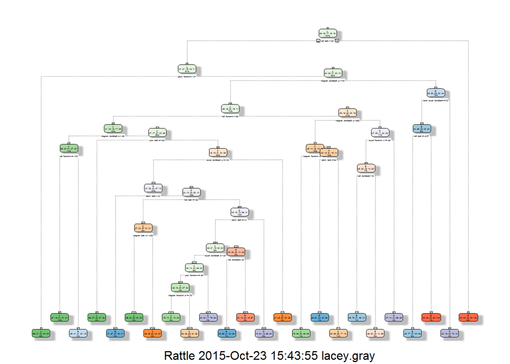

```r
##Build Model
mod1 <- rpart(classe ~., data=train, method="class")
fancyRpartPlot(mod1)
```

Let’s now predict using the remaining 40% of the data.

```r
pred1 <- predict(mod1, subTrain, type="class")
```

We can now see the results of our prediction using a confusion matrix.

```r
confusionMatrix(pred1, subTrain$classe)
```

```
## Confusion Matrix and Statistics
##
##           Reference
## Prediction    A    B    C    D    E
##          A 1970  239   19   56   22
##          B   82  898   58   91  116
##          C   67  159 1112  217  182
##          D   76  112   91  831   92
##          E   37  110   88   91 1030
##
## Overall Statistics
##
##                Accuracy : 0.7445
##                  95% CI : (0.7347, 0.7541)
##     No Information Rate : 0.2845
##     P-Value [Acc > NIR] : < 2.2e-16
##
##                   Kappa : 0.6766
##  Mcnemar's Test P-Value : < 2.2e-16
##
## Statistics by Class:
##
##                      Class: A Class: B Class: C Class: D Class: E
## Sensitivity            0.8826   0.5916   0.8129   0.6462   0.7143
## Specificity            0.9401   0.9452   0.9035   0.9434   0.9491
## Pos Pred Value         0.8543   0.7213   0.6402   0.6913   0.7596
## Neg Pred Value         0.9527   0.9061   0.9581   0.9315   0.9365
## Prevalence             0.2845   0.1935   0.1744   0.1639   0.1838
## Detection Rate         0.2511   0.1145   0.1417   0.1059   0.1313
## Detection Prevalence   0.2939   0.1587   0.2214   0.1532   0.1728
## Balanced Accuracy      0.9114   0.7684   0.8582   0.7948   0.8317
```

As we can see, our accuracy is 0.7445 with a 95% CI of (0.7347, 0.7541). We will try another modeling technique to see if we can get any better results

### Random Forest for Prediction

We will build the Random Forest with the 60% of the training dataset.

```r
mod2 <- randomForest(classe ~., data=train, method="class")
```

We will now use this model to predict the remaining 40% of the training data.

```r
pred2 <- predict(mod2, subTrain, type="class")
```

Let’s now look at the confusion matrix.

```r
confusionMatrix(pred2, subTrain$classe)
```

```
## Confusion Matrix and Statistics
##
##           Reference
## Prediction    A    B    C    D    E
##          A 2232   10    0    0    0
##          B    0 1504   11    0    0
##          C    0    4 1355   21    1
##          D    0    0    2 1264    3
##          E    0    0    0    1 1438
##
## Overall Statistics
##
##                Accuracy : 0.9932
##                  95% CI : (0.9912, 0.9949)
##     No Information Rate : 0.2845
##     P-Value [Acc > NIR] : < 2.2e-16
##
##                   Kappa : 0.9915
##  Mcnemar's Test P-Value : NA
##
## Statistics by Class:
##
##                      Class: A Class: B Class: C Class: D Class: E
## Sensitivity            1.0000   0.9908   0.9905   0.9829   0.9972
## Specificity            0.9982   0.9983   0.9960   0.9992   0.9998
## Pos Pred Value         0.9955   0.9927   0.9812   0.9961   0.9993
## Neg Pred Value         1.0000   0.9978   0.9980   0.9967   0.9994
## Prevalence             0.2845   0.1935   0.1744   0.1639   0.1838
## Detection Rate         0.2845   0.1917   0.1727   0.1611   0.1833
## Detection Prevalence   0.2858   0.1931   0.1760   0.1617   0.1834
## Balanced Accuracy      0.9991   0.9945   0.9932   0.9911   0.9985
```

In this case it is not surprising that the random forest has better accuracy. We will move forward using this for the submission part of this project.

### Submission

In the submission part of the project, we will using the Testing data provided in the assignment.

```r
##Using model 2 to predict outcomes in the test set.
fpred <- predict(mod2, cleanTest, type="class")
```

Test prediction outcomes using model 2. To keep with the Coursera honor code, I am not printing the results in this report.

```r
##fpred
```